# R Notebook

Increasingly, microbiome researchers are looking at ways to use machine learning in order to filter through OTUs and associate them with phenotypic metadata. Doing that while also accounting for the metadata covariates is a complicated task.

One recent approach, SIAMCAT, blackboxes much of the machine learning and streamlines the interface so that you mostly have to deal with interpreting the somewhat complex output figures (in my opinion).

This is a condensed version of the SIAMCAT vignette.

https://bioconductor.org/packages/release/bioc/vignettes/SIAMCAT/inst/doc/SIAMCAT_vignette.html

We will use the example dataset that is part of the SIAMCAT package itself.

# initial loading of data

Fundamentally, SIAMCAT needs two datasets.

1. an OTU table (converted to relative abundance)
2. a table of metadata to associate the OTUs with

A label is created for the main outcome variable in the metadata, and the rest are used as covariates in the downstream models.

```r
library(SIAMCAT)
data("feat_crc_zeller", package="SIAMCAT")
data("meta_crc_zeller", package="SIAMCAT")
#2 objects in memory now, feat.crc.zeller and meta.crc.zeller

#create label, Case is the affected category (Control is the baseline)
label.crc.zeller <- create.label(meta=meta.crc.zeller,
    label='Group', case='CRC')
```

```
## Label used as case:
##    CRC
## Label used as control:
##    CTR
```

```
## + finished create.label.from.metadata in    0 s
```

# create siamcat object

Here we load SIAMCAT using the simplest case where each of the inputs are dataframes. Another standard approach would be to convert phyloseq objects, which have the otu/metadata integrated into one object. See the second vignette about inputs for the full breadth of options.

https://bioconductor.org/packages/release/bioc/vignettes/SIAMCAT/inst/doc/SIAMCAT_read-in.html

# siamcat object

The basic logic to siamcat is that after you create the initial siamcat, you then add downstream results to the original object. They are placed in separate S6 slots, you can retrieve the original data as well as the downstream results.

```r
siamcat <- siamcat(feat=feat.crc.zeller,
    label=label.crc.zeller,
    meta=meta.crc.zeller)
```

```
## + starting validate.data
```

```
## +++ checking overlap between labels and features
```

```
## + Keeping labels of 141 sample(s).
```

```
## +++ checking sample number per class
```

```
## +++ checking overlap between samples and metadata
```

```
## + finished validate.data in 0.33 s
```

```r
#do some quick filtering to remove low-abundance OTUs

siamcat <- filter.features(siamcat,
    filter.method = 'abundance',
    cutoff = 0.001)
```

```
## Features successfully filtered
```

# Check associations between OTUs and metadata

```r
#start with some data normalization
# log normalize the OTUs

siamcat <- normalize.features(
    siamcat,
    norm.method = "log.unit",
    norm.param = list(
        log.n0 = 1e-06,
        n.p = 2,
        norm.margin = 1
    )
)
```

```
## Features normalized successfully.
```

```r
#split the data into training and testing partitions
#the train dataset is used for training/tuning the model
#how well it predicts it used by comparing it with the test splits

siamcat <-  create.data.split(
    siamcat,
    num.folds = 5,
    num.resample = 2
)
```

```
## Features splitted for cross-validation successfully.
```

# model training

SIAMCAT provides a simplified interface to machine learning, as compared to caret/scikit-learn where you have more control over the options but also need to know more about the hyper-parameters, etc.

Here, you mostly just select one of a few popular methods, that have various methods of feature selection.

The full list of models is: method = c(“lasso”, “enet”, “ridge”, “lasso_ll”, “ridge_ll”, “randomForest”)

```r
#train model
siamcat <- train.model(
    siamcat,
    method = "lasso"
)
```

```
## Trained lasso models successfully.
```

```r
#make predictions
siamcat <- make.predictions(siamcat)
```

```
## Made predictions successfully.
```

```r
pred_matrix <- pred_matrix(siamcat)
```

# Model evaluation

There are two final plots. The evaluate.predictions() tells us how well the method performed using ROC curves (Charley can explain maybe?)

```r
#plot the predictions as an ROC curve
siamcat <-  evaluate.predictions(siamcat)
```

```
## Evaluated predictions successfully.
```

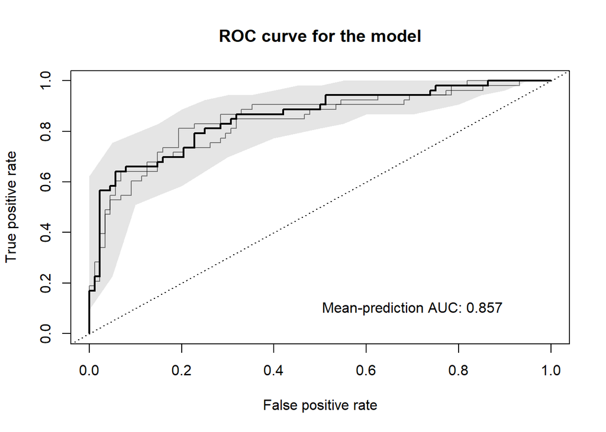

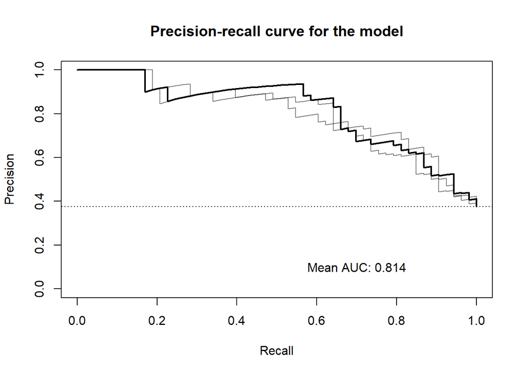

```r
model.evaluation.plot(siamcat)
```

# Model interpretation

The most complex plot output is the interpretation plot, there’s just a lot of data to associate.

There are 4 basic panels.

1. feature weight (which OTUs are most predictive)
2. heatmap of the scores for the top features across samples
3. boxplot of the variation in performance across cross-validation samples
4. the distribution of the metadata across samples

```r
model.interpretation.plot(
    siamcat,
    fn.plot = 'interpretation.pdf',
    consens.thres = 0.5,
    limits = c(-3, 3),
    heatmap.type = 'zscore',
)
```

```
## Successfully plotted model interpretation plot to: interpretation.pdf
```